# STA 32 R Project

Ahmed Farooqui & Hammad Zahid

June 8th, 2018

# Problem 1

### (a)

The standard deviation of the normalized vector is 1. This function was quite simple; I simply took the vector, subtracted by the mean, divided by the standard deviation, and returned the standard deviation of that result

### (b)

Lower bound is -7.522984 and the high is 108.522984. This function was also quite simple. I found the mean and standard deviation. I returned a list of the upper and lower bounds.

### (c)

The selective mean is 50.5. For this answer, I looped through every element in the vector, and checked it against the bounds being greater than 3 or less that -3. If true, I would reduce the size of the vector by 1, simulating removing an element from the vecotr. The else case updates a sum variable, which adds the current element to the sum. After the loop, I returned the mean based on the sum and the modified size.

# Problem 2

### (a)

The probability a “head” is encountered for 20 flips is 0.55. Using sample, with N flips, I determined the probability by summing all the ones encountered then dividing by the number of trials.

### (d)

As the value of N gets bigger, the error gets smaller. This makes sense, as increasing the number of flips makes the probability of one side move closer and closer to half, given that the coin flip is fair.

# Problem 3

### (a)

The draw for 7 times on 7 values looks like this: 5, 2, 6, 1, 3, 4, 7. I replicated the sample 7 times. This function returns a matrix with columns that represent each set of 7 draws.

### (d)

The number of unique orderings is 5040. Duplicated returns the rows that are unique. So, taking the transpose of the matrix and calling duplicated should return the columns of the original matrix. Then, referencing the unique columns in the original matrix returns another matrix that I assigned to a temp. Then, I asked for the number of columns in the new matrix.

# Problem 5

### (a)

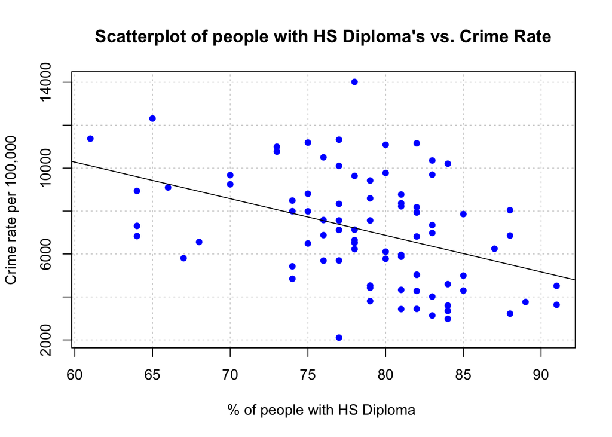

#### Summary statistics for our regression line

```
##
## Call:
## lm(formula = Y ~ X)
##
## Residuals:
##     Min      1Q  Median      3Q     Max
## -5278.3 -1757.5  -210.5  1575.3  6803.3
##
## Coefficients:
##             Estimate Std. Error t value Pr(>|t|)
## (Intercept) 20517.60    3277.64   6.260 1.67e-08 ***
## X            -170.58      41.57  -4.103 9.57e-05 ***
## ---
## Signif. codes:  0 '***' 0.001 '**' 0.01 '*' 0.05 '.' 0.1 ' ' 1
##
## Residual standard error: 2356 on 82 degrees of freedom
## Multiple R-squared:  0.1703, Adjusted R-squared:  0.1602
## F-statistic: 16.83 on 1 and 82 DF,  p-value: 9.571e-05
```

### (b)

The algebraic regression line formula is ŷi =βO + β1xi+ε Thus from our **summary statistics above**, we can input our values and our regression line formula is **ŷi = 20517 + -170.58xi + ε** where ε ~ N(0, 2356^2 )

=> From Estimate in Intercept row β0 = 20517

=> From Estimate in X row β1 = -170.58

=> From Residual standard error σ = 2356

### (c)

The intercept is 20517 and the slope is -170.58x. This tells us that at the crime 20517, for each 1% increase of people with HS diplomas, we decrase crime by approximately 170.58 or 171 people.

### (d)

We used the boxplot method from the lecture 1 notes to determine our outliers. The details are in our code appendix. We did not have any outliers on the higher end of the scatter plot. The result for the LargerOutlier function in our code returned null. However on the lower end of the scatter plot we found there are 6 outliers. This is seen by the output of our SmallOutlier function. The results are as follows:

The **1st column** (6, 20, 39, etc.) is the **row number**, the **2nd column** (9100, 12311, etc. ) is **rate OR Y** and the **3rd column** (66, 65, etc.) is **dip OR X**. We have 6 outliers and they are as follows:

#### List of Outliers

```
##     rate dip
## 6   9100  66
## 20 12311  65
## 39 11371  61
## 51  7309  64
## 71  6836  64
## 76  8937  64
```

### (e)

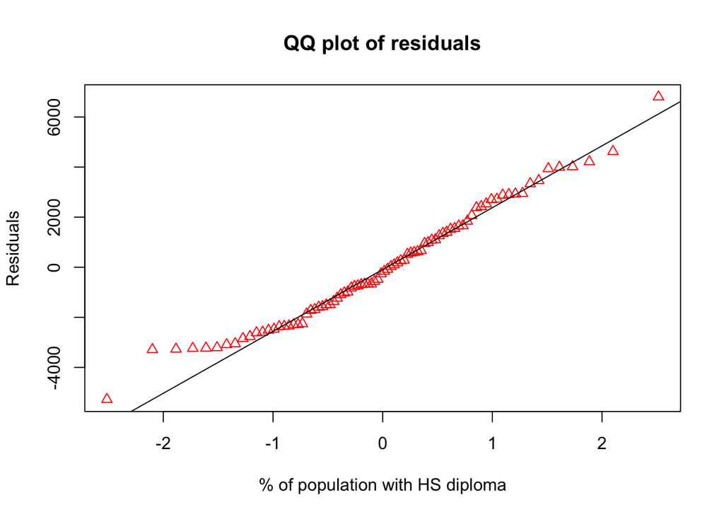

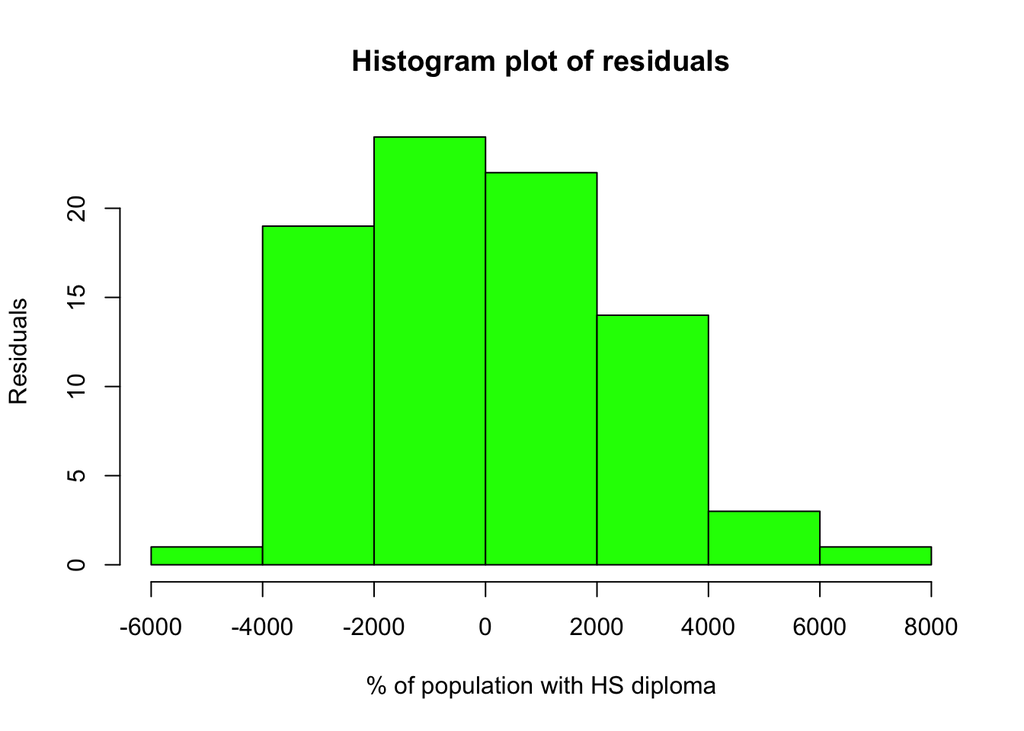

The deviations from the straight line are minimal. This indicates normal distribution. We wanted to confirm our results to vindicate that the distribution is normal so we also made a histogram.

### (f)

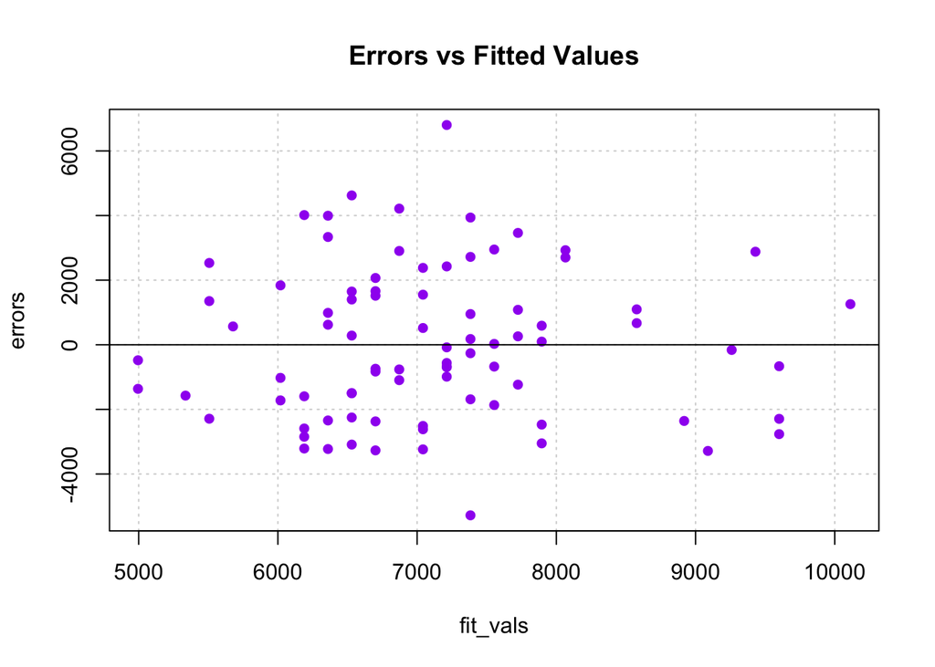

Yes it appears that the variance in errors in constant. This is shown by the plotted regression line which is horizontal with no slope.

### (g)

The following is our 95% confidence interval for the slope. We are 95% confident that the slope falls within -253.2798 and -87.8706. This means that for every 1% increase in people with high school diplomas, there is a decrease in crime by between 88 and 253 people. We round the interval to whole numbers because people are discrete values. The interval suggests that there is a significant linear relationship between X and Y. This is clear because the interval excludes 0, therefore we can rule out the liklihood that the slope is 0. Therefore there is a significant linear relationship.

#### 95% confidence interval

```
##     2.5 %    97.5 %
## -253.2798  -87.8706
```

## Appendix Code

```r
###Problem 1
  #(a)
  norm <- function(x){
    meanvec <- mean(x)
    sdvec <- sd(x)
    returnvec <- (x - meanvec) / sdvec
    sd(returnvec)
  }

  #(b)
  lowhigh <- function(x){
    meanvec <- mean(x)
    sdvec <- sd(x)
    lower <- meanvec - 2*sdvec
    higher <- meanvec + 2*sdvec
    lowerhigher <- list(lower,higher)
    lowerhigher
  }

  #(c)
  selectivemean <- function(x){
    sum <- 0
    size = length(x)
    meanvec <- mean(x)
    sdvec <- sd(x)

    for(i in 1:length(x)){
      bounds <- (x[i] - meanvec) / sdvec
      if(bounds > 3 | bounds < -3){
        size = size - 1
      }else{
        sum = sum + x[i]

      }
    }

    meannewvec <- sum / size
    meannewvec
  }

  X <- 1:100
  ans1 <- norm(X)
  ans2 <- lowhigh(X)

  X = c(1:100,200,300)
  ans3 <- selectivemean(X)


###Problem 2
  #(a)
  flip <- function(N){
    flips <- sample(0:1, N, replace = TRUE)
    sum(flips==1) / N
  }

  ans1 = flip(20)

  #(b)
  x <- list(10, 100, 1000, 10000, 100000)

  ans2 <- sapply(x, flip)

  #(c)
  error <- function(x){
    abs(0.5 - head(x))
  }

  ans3 <- sapply(ans2, error)


###Problem 3
  values = as.character(1:7)

  #(a)
  perm <- function(x,numexperiments){
    replicate(numexperiments,sample(x,length(x),replace = FALSE))
  }

  #ans1
  mat <- perm(values, 7)
  ans1 <- list(mat[1,1], mat[2,1], mat[3,1], mat[4,1], mat[5,1], mat[6,1], mat[7,1])

  #(b)
  onethere <- function(x){
    counter <- 0
    for(i in 1:100000){
      if(x[1, i] == 1){
        counter = counter + 1
      }
    }
    counter
  }

  mat2 <- perm(values, 100000)
  ans2 <- onethere(mat2)

  #(c)
  startendthreeseven <- function(x){
    counter <- 0
    for(i in 1:100000){
      if(x[1, i] == 3 & x[7, i] == 7){
        counter = counter+1
      }
    }
    counter/100000
  }

  ans3 <- startendthreeseven(mat2)

  #(d)
  uniquecol <- duplicated(t(mat2))
  mat3 <- mat2[, !uniquecol]
  size <- ncol(mat3)

##PROBLEM 5

##(a)
crime <- read.csv("crime.csv", header = TRUE)

#Y is the crime rate
Y = crime$rate
#X is the number of people with HS diploma per 100,000
X = crime$dip

plot(X, Y, main="Scatterplot of people with HS Diploma's vs. Crime Rate",
    xlab="% of people with HS Diploma ", ylab="Crime rate per 100,000", pch = 16,col = "blue",grid(nx = NULL, ny = NULL, col = "lightgray", lty = "dotted"))


abline(lm(Y ~ X))
fit <- lm(Y~X)
summary(fit)
#From Estimate in Intercept row
β0 = 20517
#From Estimate in X row
β1 = -170.58
#From Residual standard error
σ = 2356

##(d)
Q1 = quantile(crime$dip, probs = (0.25))
Q3 = quantile(crime$dip, probs = (0.75))
IQR= Q3 - Q1
OutlierBig = Q3 + (1.5*IQR)
OutlierSmall = Q1 - (1.5*IQR)
SmallOutlier <- subset(crime, dip < OutlierSmall)
LargerOutlier <- subset(crime, dip > OutlierBig)

SmallOutlier
##(e)
crime.lm = lm(Y~X, data = crime)
crime.stdres = residuals(crime.lm)

qqnorm(crime.stdres, ylab = "Residuals", xlab = "% of population with HS diploma", main = "QQ plot of residuals", pch = 2, col = "red", )
qqline(crime.stdres)
hist(crime.stdres,ylab = "Residuals", xlab = "% of population with HS diploma", main = "Histogram plot of residuals", col = "green")

##(f)
fit_vals = fitted.values(fit)
errors = crime.stdres
plot(fit_vals, errors,main = "Errors vs Fitted Values", pch = 16, col = "purple",grid(nx = NULL, ny = NULL, col = "lightgray", lty = "dotted"))
regress = lm(errors ~ fit_vals)
slope = abline(regress)

##(g)
round(confint(fit)[2,],digits = 4)
```